# PC practical: Descriptive Statistics

## RStudio

Start RStudio through Athena or install it freely from https://www.rstudio.com/products/RStudio/.

RStudio consists of

- console (question-answer principle & case-sensitive)
- scriptfile (.R) or Markdownfile (.Rmd) or data
- workspace & history
- files/plots/…

## Exercise 1

Read in data set lovett.dat

1. via File > Import dataset > From Text File (Heading: yes, Separator: Tab, Decimal: Comma)

or

2. via the command (be careful with the location of the file)

```r
lovett <- read.table("lovett.dat", header = TRUE, sep = "\t", dec = ",")
```

When you don’t know exactly what a command does, or what arguments are available for a certain command, you can open the help file of this command by using a question mark. For example:

```r
?read.table
```

```
## starting httpd help server ... done
```

To ensure that `R` recognises the column names:

```r
attach(lovett)
MAXELEV
```

```
##  [1] 1006 1216 1204 1213 1074 1113 1027 1234 1234 1137 1061 1173 1125 1018 1171
## [16] 1076 1171  939 1277 1180 1161 1030 1076 1021  754 1039  762  863 1137 1091
## [31] 1137 1186 1173  957  887  983 1219 1231
```

### Question 1

How many study sites (streams) were observed?

```r
nrow(lovett)
```

```
## [1] 38
```

### Question 2

Suppose that for a certain site no concentration NH4- ions was introduced, would you then enter this as a value ‘0’ or as a missing value?

Missing values should be entered as ‘NA’.

### Question 3a

1. How many sites have an elevation above / below 500m above sea level? Create a frequency table to see this and a bar chart.

Univariate inspection of the categorical variable HEIGHT

```r
table(HEIGHT)
```

```
## HEIGHT
##  0  1
## 16 22
```

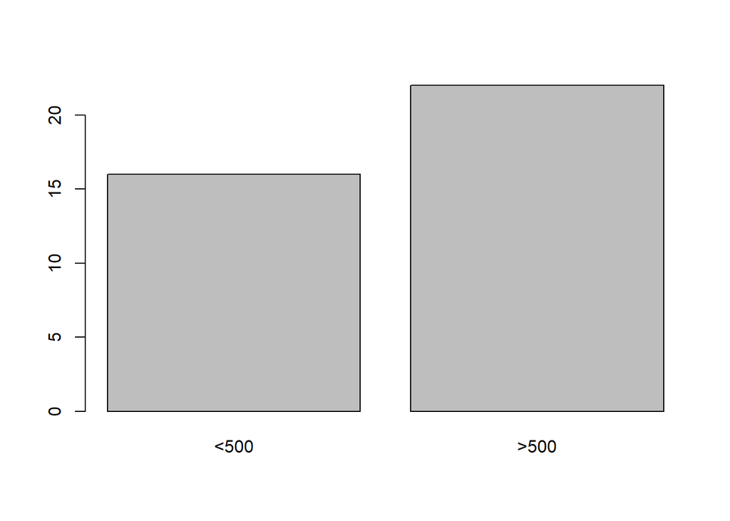

```r
tab <- table(HEIGHT)
barplot(tab, names = c("<500",">500"))
```

### Question 3b

2. Create a stem-and-leaf plot for the height of the site. What can be said about the distribution of the data? Are there any outliers? Make also a histogram and a kernel density estimator.

```r
stem(SAMPELEV)
```

```
##
##   The decimal point is 2 digit(s) to the right of the |
##
##   2 | 79
##   3 | 136
##   4 | 1233556668
##   5 | 013367899
##   6 | 1122233366788
##   7 | 9
```

Univariate inspection of the continuous variable SAMPELEV

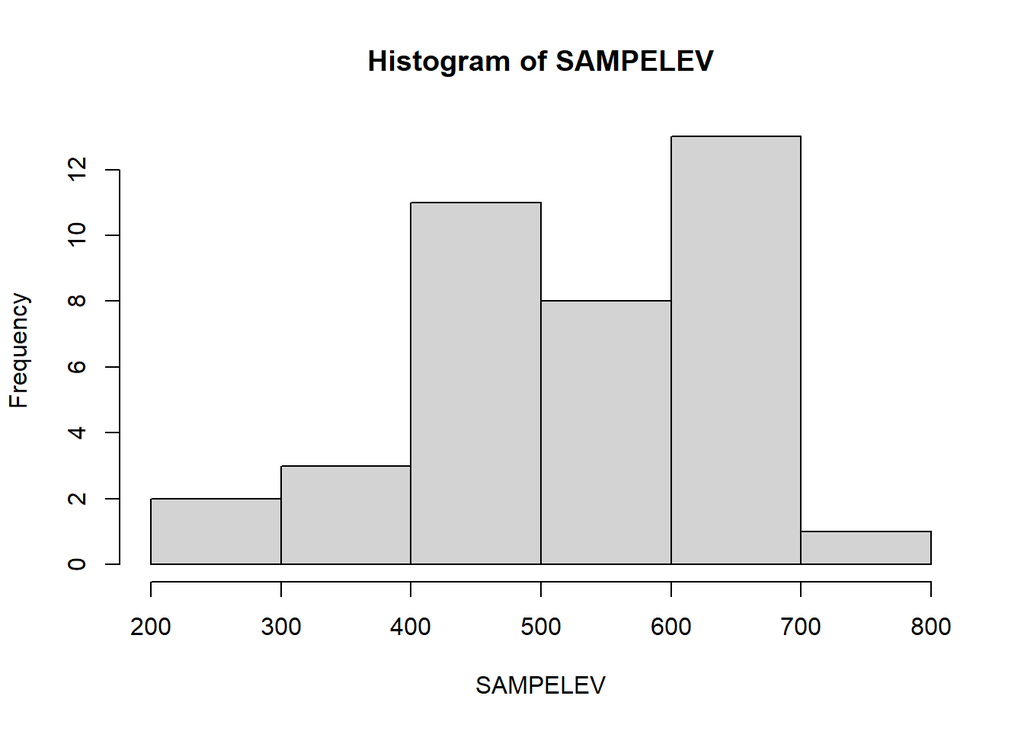

```r
hist(SAMPELEV)
```

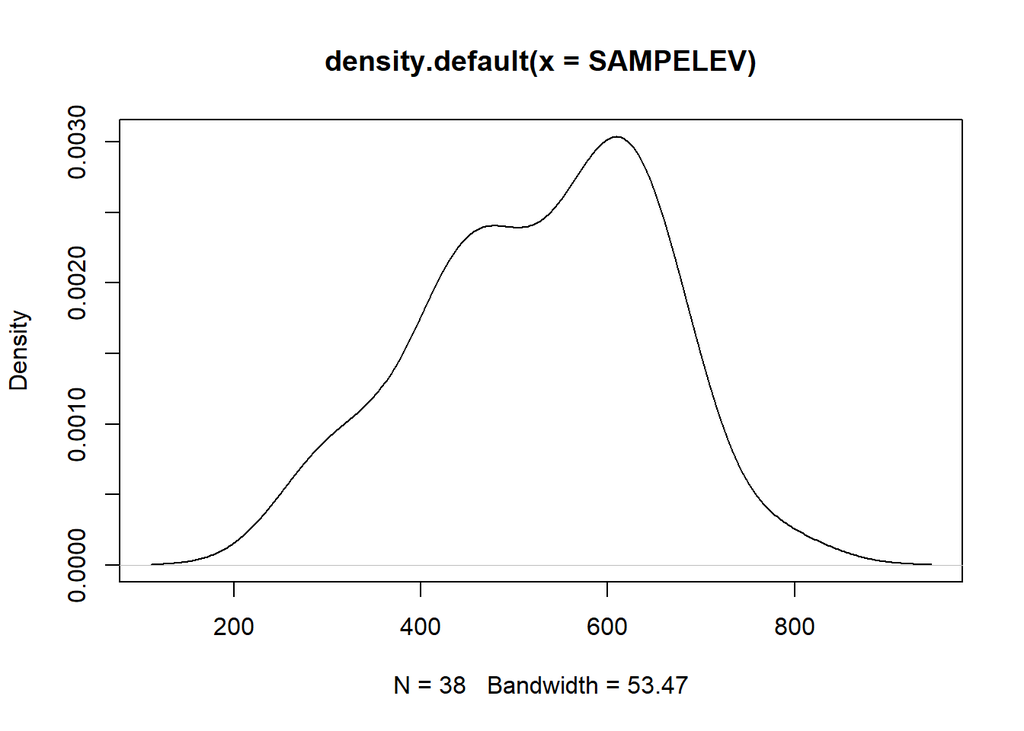

```r
plot(density(SAMPELEV))
```

### Question 3c

3. Calculate for the concentrations NH4-, SO4 -2 and Cl:
- The mean and median (and order them from small to large)
- The standard deviation and interquartile range
- The minimum and maximum (are there any improbable observations that might indicate measure or typing errors?)

Univariate inspection of the continuous variables NH4, SO4, CL

For example, for CL

```r
mean(CL)
```

```
## [1] 23.07368
```

```r
median(CL)
```

```
## [1] 20.55
```

Mean > median: is this always the case? Explanation? What is best measure of location?

```r
standdev <- sqrt(var(CL))
##or
standdev <- sd(CL)
standdev
```

```
## [1] 12.46261
```

```r
quantiles <- quantile(CL, probs = c(.25,.75))
quantiles
```

```
##    25%    75%
## 16.875 23.900
```

```r
intquart <- quantiles[2] - quantiles[1]
##or
intquart <- diff(quantiles)
intquart
```

```
##   75%
## 7.025
```

```r
##or
IQR(CL)
```

```
## [1] 7.025
```

```r
min(CL)
```

```
## [1] 13
```

```r
max(CL)
```

```
## [1] 78.8
```

Boxplot for CL

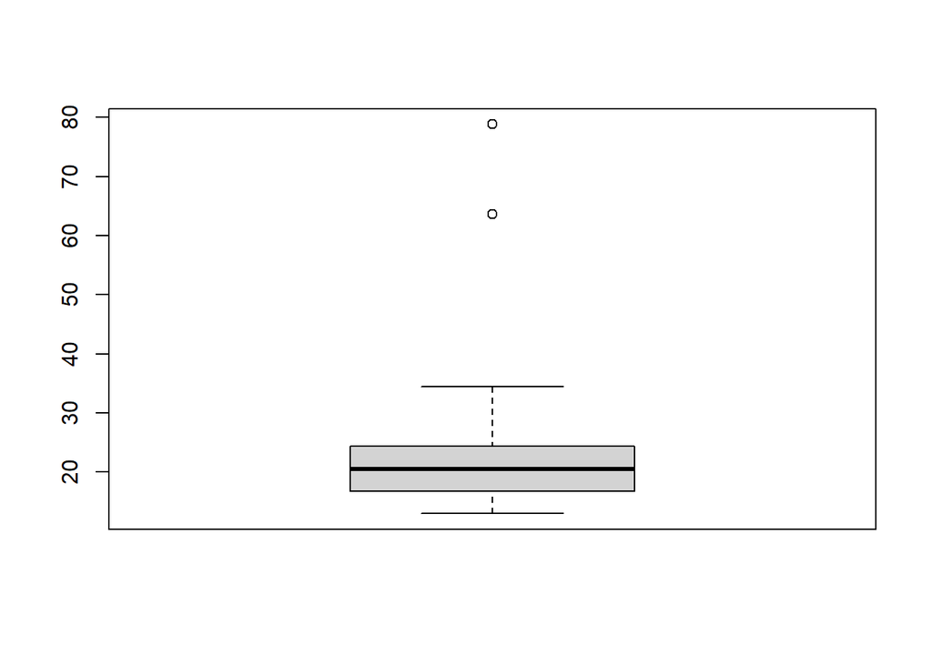

```r
boxplot(CL)
```

Outlier = observation $x$ for which $x>x_{75}$+1.5 $\cdot$ IQR or $x<x_{25}$-1.5 $\cdot$ IQR.

For CL: $x_{75}$+1.5 $\cdot$ IQR = 23.9 + 1.5 $\cdot$ 7.025 = 34.4375 < max, so outlier(s) for large values

$x_{25}$-1.5 $\cdot$ IQR = 16.875 - 1.5 $\cdot$ 7.025 = 6.3375 < min, thus no outliers for small values

Take care: whiskers run to the smallest/largest observed value that is not an outlier!

Taking missing data into account:

```r
mean(CL, na.rm = T)
```

```
## [1] 23.07368
```

```r
mean(NH4, na.rm = T)
```

```
## [1] 1.647368
```

```r
mean(SO4, na.rm = T)
```

```
## [1] 62.07895
```

```r
mean(CL, na.rm = T)
```

```
## [1] 23.07368
```

```r
median(NH4, na.rm = T)
```

```
## [1] 1.4
```

```r
median(SO4, na.rm = T)
```

```
## [1] 62.1
```

```r
median(CL, na.rm = T)
```

```
## [1] 20.55
```

```r
sqrt(var(NH4, na.rm = T))
```

```
## [1] 0.7321707
```

```r
sqrt(var(SO4, na.rm = T))
```

```
## [1] 5.219514
```

```r
sqrt(var(CL, na.rm = T))
```

```
## [1] 12.46261
```

```r
IQR(NH4, na.rm = T)
```

```
## [1] 1.1
```

```r
IQR(SO4, na.rm = T)
```

```
## [1] 7.8
```

```r
IQR(CL, na.rm = T)
```

```
## [1] 7.025
```

```r
min(NH4, na.rm = T)
```

```
## [1] 0.6
```

```r
min(SO4, na.rm = T)
```

```
## [1] 50.6
```

```r
min(CL, na.rm = T)
```

```
## [1] 13
```

```r
max(NH4, na.rm = T)
```

```
## [1] 3.3
```

```r
max(SO4, na.rm = T)
```

```
## [1] 72.1
```

```r
max(CL, na.rm = T)
```

```
## [1] 78.8
```

Or for all 3 variables together by using ‘apply’:

```r
mat <- cbind(NH4, SO4, CL)

means <- apply(mat, 2, mean, na.rm = T)
means
```

```
##       NH4       SO4        CL
##  1.647368 62.078947 23.073684
```

```r
medians <- apply(mat, 2, median, na.rm = T)
medians
```

```
##   NH4   SO4    CL
##  1.40 62.10 20.55
```

```r
apply(mat, 2, IQR, na.rm = T)
```

```
##   NH4   SO4    CL
## 1.100 7.800 7.025
```

### Question 3d

4. Create a new variable ‘NH4CAT’ which indicates for each stream whether the concentration NH4- is smaller than 1.5 mol/l or not.

```r
NH4CAT = ifelse(NH4<1.5, 0, 1)
table(NH4CAT)
```

```
## NH4CAT
##  0  1
## 21 17
```

### Question 4a

1. Create a dot plot and a boxplot to compare the distribution of the NH4- concentration in both groups of HEIGHT. Carefully describe how the distribution differs between both groups and draw a conclusion.

Association between continuous and categorical variable: dot plot and boxplot

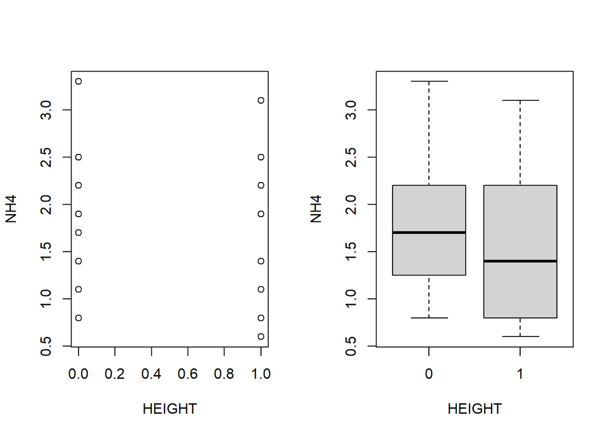

```r
par(mfrow = c(1,2))
plot(HEIGHT, NH4)
boxplot(NH4 ~ HEIGHT)
```

### Question 4b

2. Are there, relatively speaking, more low NH4- concentrations (‘NH4CAT’=0) for the higher or the lower sites? Do you see any association between the height of the site and the NH4- concentration?

Association between 2 categorical variables: cross table

```r
table(HEIGHT, NH4CAT)
```

```
##       NH4CAT
## HEIGHT  0  1
##      0  7  9
##      1 14  8
```

### Question 4c

3. Create a scatterplot of the NH4- concentration in function of the height of the site and describe the observed association. Calculate also the correlation. What would the point cloud of the scatterplot look like if the NH4- concentration and the height of the site were not associated?

Association between 2 continuous variables: scatterplot and correlation

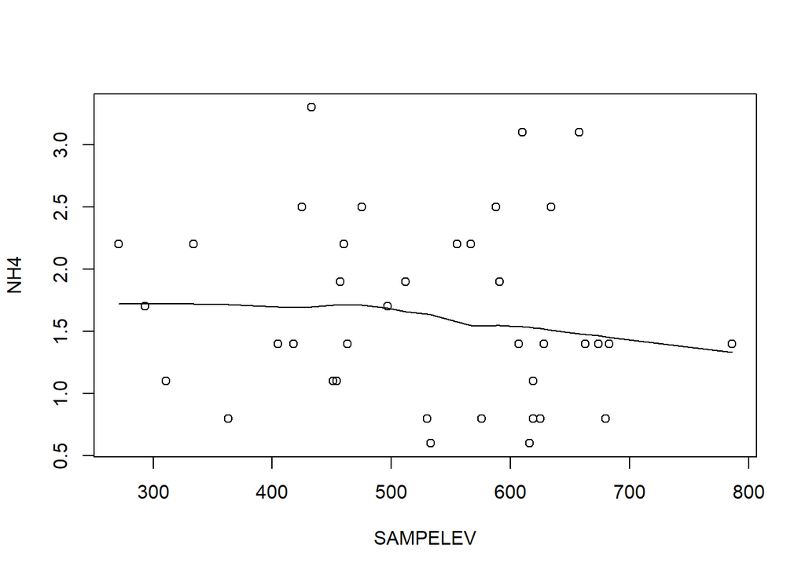

```r
par(mfrow = c(1,1))
plot(SAMPELEV, NH4)
lines(lowess(SAMPELEV, NH4))
```

```r
cor(SAMPELEV, NH4)
```

```
## [1] -0.11694
```

### Question 5a

1. Can we use this dataset to investigate the causal effect of the height of the study site on the concentration NH4- ?

We can’t investigate the causal effect of the height of the study site on the concentrations, because we are dealing with observational data. The height of the study sites was not experimentally manipulated. Unknown confounders may be the cause of an association between the height of the study site and the concentrations.

Causality: One variable preceding is a cause of the other suceeding. Correlation: The situation which multiple variables move together.

### Question 5b

2. What other factors might play a role? How could you correct for those factors in the analysis?

Other measured or unmeasured variables may be associated both with height and the concentrations. F.e. the maximal elevation may be associated both with the height of the site and the concentration. We adjust for this variable by including this variable as covariate in your model. We can’t adjust for unmeasured confounders.

## Exercise 2

The dataset ‘tusks.dat’ contains data on the tusks of elephants found by rangers in the Mikumi National Park in Tanzania. Each time a ranger finds a dead elephant while on patrol, the following variables are recorded:

• number: the number of remaining tusks: 0, 1, or 2. Sometimes an elephant is born with only 1 (or without) tusk. It might also be that poachers already took the tusks.

• mass1: mass in kilogram of the first tusk. The order of measuring the tusks is random.

• mass1cat: mass category of the first tusk: 5=heavy, 4=medium–heavy, 3=medium, 2=medium–light, 1=light.

• mass2: weight in kilogram of the second tusk. If only 1 tusk was found, this value is missing.

• cause: cause of death: by poachers (=2), by park management in life threatening situations for rangers, villagers or tourists (=3), by disease (=5), hit by a train (=7) or unknown (=1).

Read in data set `tusks.dat`.

```r
tusks <- read.table("tusks.dat", header = TRUE, sep = "\t", dec = ",")
```

### Question 1

Define for each variable the type of variable.

```r
str(tusks)
```

```
## 'data.frame':    24 obs. of  5 variables:
##  $ number  : int  2 2 2 1 2 1 1 2 2 1 ...
##  $ mass1   : num  9.03 12.03 4.5 2.5 1.5 ...
##  $ mass1cat: int  4 5 2 1 1 1 1 1 1 2 ...
##  $ mass2   : num  9.03 13 3.5 NA 1 NA NA 1.5 2.75 NA ...
##  $ cause   : int  2 3 2 1 1 1 2 2 5 7 ...
```

### Question 2

Create a frequency table and bar plot for the qualitative and numerical discrete variables. Interpret.

```r
# frequency tables
table(tusks[, "number"])
```

```
##
##  1  2
## 11 13
```

```r
table(tusks[, "mass1cat"])
```

```
##
##  1  2  4  5
## 12  7  2  3
```

```r
table(tusks[, "cause"])
```

```
##
##  1  2  3  5  7
##  7 10  2  4  1
```

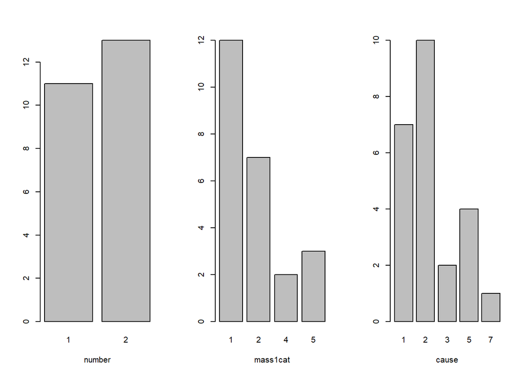

```r
# barplots
par(mfrow = c(1, 3))
for(var in c("number", "mass1cat", "cause")){
  # barplots
  barplot(table(tusks[, var]), xlab = var)
}
```

### Question 3

Calculate appropriate summary measures for the continuous variables and compare them in terms of location and spread. Look at the distribution of the variables using histograms and describe it. Are they approximately normal? Verify using QQ-plots.

```r
# summary measures

# histograms

# qqplots
# use qqnorm(), and qqline()
```